# hw-02

Your Name (S2569127)

2023-11-03

## Exercise 1

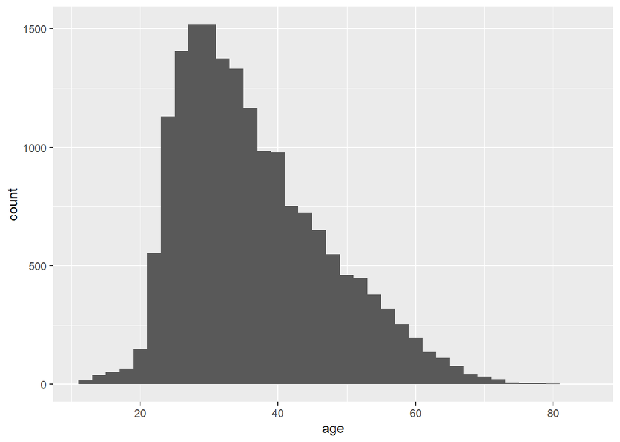

```r
run17 %>%
  filter(event == "10 Mile") %>%
  ggplot(mapping = aes(x = age)) +
    geom_histogram(binwidth = 2)
```

```r
#statistics calculations code

run17%>% filter(event == "10 Mile") %>%
         filter(age <20)
```

```
## # A tibble: 169 × 9
##      bib name         sex     age city          net_sec clock_sec pace_sec event
##    <int> <chr>        <chr> <int> <chr>           <dbl>     <dbl>    <dbl> <chr>
##  1  3799 Claudia M.   F        17 Mexico City,…    4242      4486      424 10 M…
##  2  7883 Natalia G.   F        17 Washington, …    4347      4533      434 10 M…
##  3  5995 Stephanie J. F        18 State Colleg…    4368      4560      436 10 M…
##  4  5280 Jennah H.    F        18 Bethesda, MD     4503      5427      450 10 M…
##  5  2235 Avery A.     F        17 Eldersburg, …    4513      4781      451 10 M…
##  6  4584 Elaina S.    F        15 Vienna, VA       4561      4841      456 10 M…
##  7  2024 Leah K.      F        14 Bethesda, MD     4563      4833      456 10 M…
##  8 22527 Caroline M.  F        19 Bethesda, MD     4650      4834      465 10 M…
##  9  3614 Jamie F.     F        19 Binghamton, …    4651      4836      465 10 M…
## 10  5978 Caroline C.  F        18 Lexington, VA    4651      4835      465 10 M…
## # ℹ 159 more rows
```

```r
run17 %>% filter(event == "10 Mile") %>%
         filter( age > 75)
```

```
## # A tibble: 11 × 9
##      bib name       sex     age city            net_sec clock_sec pace_sec event
##    <int> <chr>      <chr> <int> <chr>             <dbl>     <dbl>    <dbl> <chr>
##  1   415 Heide M.   F        78 Lancaster, PA      5968      5972      596 10 M…
##  2   426 Imme D.    F        80 Princeton, NJ      7015      7020      701 10 M…
##  3   403 Malcolm O. M        77 Chevy Chase, MD    5703      6003      570 10 M…
##  4 23173 George Y.  M        85 Towson, MD         6248      6260      624 10 M…
##  5 16205 Louis G.   M        77 Sterling, VA       6427      7620      642 10 M…
##  6 12089 Don P.     M        79 Conway, AR         6517      7599      651 10 M…
##  7   417 Ken Q.     M        79 Vienna, VA         6668      6705      666 10 M…
##  8 14862 Chuck A.   M        77 Frisco, TX         6818      7866      681 10 M…
##  9 19461 Ronald S.  M        78 Arlington, VA      7065      8029      706 10 M…
## 10 19183 John F.    M        76 Clarksburg, MD     7579      8826      757 10 M…
## 11   432 Alan R.    M        81 Reston, VA         8251      8290      825 10 M…
```

```r
run17 %>% filter(event == "10 Mile") %>%
          summarise( min_age = min(age),
                    max_age = max(age))
```

```
## # A tibble: 1 × 2
##   min_age max_age
##     <int>   <int>
## 1      11      85
```

#1a There is very few runners aged below 20,only 169, the majority of runners are aged between early 20’s to late 40’s, shown by a mean of 37. There is a steady decrease of runners past the age 42 until very few run at the oldest age of 85. The youngest runner was 11 and the oldest runner was 85.

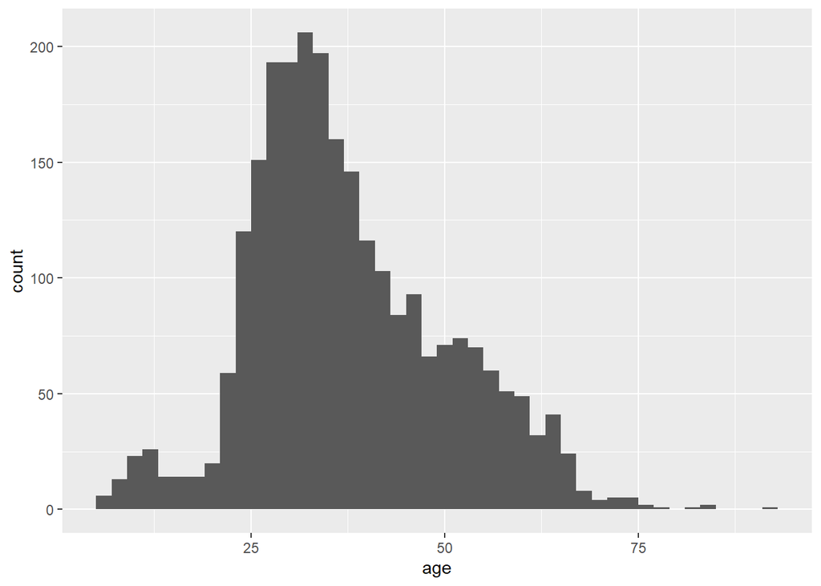

```r
# Write your code for Ex1b here
run17 %>%
  filter(event == "5K") %>%
  ggplot(mapping = aes(x = age)) +
    geom_histogram(binwidth = 2)
```

```r
#statistics calculations code

run17 %>% filter(event == "5K") %>%
  filter(age < 20) %>%
  arrange(desc(age))
```

```
## # A tibble: 110 × 9
##      bib name        sex     age city           net_sec clock_sec pace_sec event
##    <int> <chr>       <chr> <int> <chr>            <dbl>     <dbl>    <dbl> <chr>
##  1 24822 Lauren S.   F        19 Washington, DC    2116      2515      680 5K
##  2 24236 Georgia K.  F        19 Easton, PA        2276      2417      731 5K
##  3 24526 Emily F.    F        19 York, PA          2607      2723      838 5K
##  4 24961 Benjamin W. M        19 Sykesville, MD    1609      1609      517 5K
##  5 13379 Ryan P.     M        19 Huntingtown, …    2428      2444      780 5K
##  6 24068 Annah O.    F        18 Mendham, NJ       1576      1591      506 5K
##  7 25159 Ariana M.   F        18 Woodbridge, VA    2247      2294      722 5K
##  8 24449 Yuna K.     F        18 New York, NY      2371      2447      762 5K
##  9 24531 Destiny M.  F        18 Clinton, MD       3043      3068      978 5K
## 10 24184 Isabella B. F        18 Fairfax, VA       3548      3682     1140 5K
## # ℹ 100 more rows
```

```r
run17%>% filter(event == "5K") %>%
         filter(age>75)
```

```
## # A tibble: 7 × 9
##     bib name          sex     age city          net_sec clock_sec pace_sec event
##   <int> <chr>         <chr> <int> <chr>           <dbl>     <dbl>    <dbl> <chr>
## 1 24204 Mandy W.      F        76 Falls Church…    2237      2316      719 5K
## 2 23539 Jacqueline O. F        85 Washington, …    2786      2821      895 5K
## 3 25251 Stella C.     F        82 Rehoboth Bea…    4031      4218     1296 5K
## 4 23414 David F.      M        79 Washington, …    2777      2843      892 5K
## 5 14084 Jon V.        M        77 Annapolis, MD    2858      2865      918 5K
## 6 23759 Dixon H.      M        92 Fairfax Sta,…    3997      4115     1285 5K
## 7 25263 Alberto C.    M        85 Rehoboth Bea…    4030      4218     1295 5K
```

#1b In the 5K event there were less runners under 20. In the 5K event there was only 110 runners under 20 compared to 169 runners in the 10 Mile event. In the 5K event there were a lot fewer runners who were over the age of 75. In the 10 Mile event there was 11 runners aged over 75 compared to only 7 runners in the 5K event. The youngest in the 5K run was 6, however the youngest runner in the 10 Mile run was 11. The oldest runner in the 5K event was 92, however the oldest runner in the 10 Mile event was 85. This means that the 5K event had the oldest and youngest runner. The majority if runners in both the 5K event and the 10 Mile event were aged between 20 and 40. In the 5K event there were a lot less runners who attended, only 2519, compared to 17442 runners in the 10 Mile event.

## Exercise 2

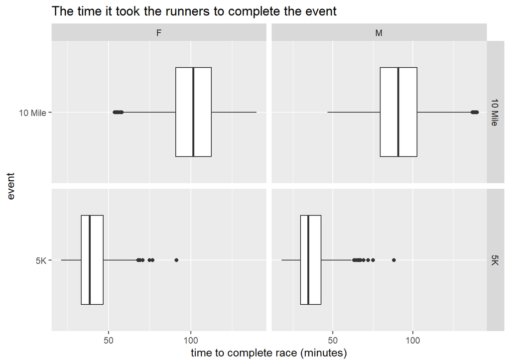

```r
# Write your code to answer exercise 2a here

ggplot(data = run17,
       mapping = aes(
         x = net_sec/60,
        y = event
       )) +
  geom_boxplot() +
  labs(
    x = "time to complete race (minutes)" ,
    y = "event" ,

    title = "The time it took the runners to complete the event"
  ) +
  facet_grid(event ~ sex,
             scale = "free")
```

#2b The female runners have a higher median than the male runners in the 10 Mile event. The female runners again have a slightly higher median than the male runners in the 5K event. The difference in the median between males and females in greater in the 10 Mile event than in the 5K event. There was a wider range of results (the time taken to complete the race) in the 10 Mile event than in the 5K event.

## Exercise 3

```r
# Write your code to answer exercise 3 here

run17 %>% filter(event == "10 Mile") %>%
          mutate(clock_net = clock_sec - net_sec) %>%
          filter(clock_net <= 180)
```

```
## # A tibble: 1,409 × 10
##      bib name       sex     age city  net_sec clock_sec pace_sec event clock_net
##    <int> <chr>      <chr> <int> <chr>   <dbl>     <dbl>    <dbl> <chr>     <dbl>
##  1     6 Hiwot G.   F        21 Ethi…    3217      3217      321 10 M…         0
##  2    22 Buze D.    F        22 Ethi…    3232      3232      323 10 M…         0
##  3    16 Gladys K.  F        31 Kenya    3276      3276      327 10 M…         0
##  4     4 Mamitu D.  F        33 Ethi…    3285      3285      328 10 M…         0
##  5    20 Karolina … F        35 Pola…    3288      3288      328 10 M…         0
##  6     8 Firehiwot… F        33 Ethi…    3316      3316      331 10 M…         0
##  7    18 Tara W.    F        27 Port…    3334      3334      333 10 M…         0
##  8    24 Nancy N.   F        21 Kenya    3357      3357      335 10 M…         0
##  9    44 Hannah D.  F        26 Sara…    3359      3359      335 10 M…         0
## 10    30 Susanna S. F        26 Rest…    3372      3372      337 10 M…         0
## # ℹ 1,399 more rows
```

```r
run17 %>% filter(event == "10 Mile") %>%
          mutate(clock_net = clock_sec - net_sec) %>%
          filter(clock_net >= 1380)
```

```
## # A tibble: 1,664 × 10
##      bib name       sex     age city  net_sec clock_sec pace_sec event clock_net
##    <int> <chr>      <chr> <int> <chr>   <dbl>     <dbl>    <dbl> <chr>     <dbl>
##  1 11626 Megan S.   F        23 Wash…    4491      5928      449 10 M…      1437
##  2 20712 Julianne … F        30 Wash…    4632      6074      463 10 M…      1442
##  3 22188 Kylie L.   F        26 Arli…    4677      6127      467 10 M…      1450
##  4  3341 Amanda A.  F        27 Newt…    4706      6146      470 10 M…      1440
##  5 20886 Monique Y. F        38 Wash…    4760      6273      476 10 M…      1513
##  6 19196 Anya K.    F        21 Oakl…    4840      6244      484 10 M…      1404
##  7 21529 Sarah C.   F        31 Silv…    4882      6286      488 10 M…      1404
##  8 21554 Angie E.   F        43 Rest…    4900      6415      490 10 M…      1515
##  9  3084 Casey H.   F        29 New …    4925      6365      492 10 M…      1440
## 10  3034 Maureen K. F        43 Beth…    5012      6453      501 10 M…      1441
## # ℹ 1,654 more rows
```

```r
First_wave = run17 %>%  filter(event == "10 Mile") %>%
          mutate(clock_net = clock_sec - net_sec) %>%
          filter(clock_net >= 1380)

Last_wave = run17 %>% filter(event == "10 Mile") %>%
          mutate(clock_net = clock_sec - net_sec) %>%
          filter(clock_net >= 1380)
```

## Exercise 4

#### Example of a bad data visualisation

[figure not shown]

Image 1 is taken from a news article which is about global warming.

Matt McGrath/BBC, “Carbon emissions threaten 1.5C climate threshold sooner than thought - report” [Online]. Available at: https://www.bbc.co.uk/news/science-environment-67242386 (Accessed: 03 NOvember 2023)

The above image presents a bad data visualisation because:

- *Reason 1* The reader cannot read any of the data specifically. This fault shows that it is a bad visualisation as it does not respect the people. There is too much data for the visualisation to be readable.
- *Reason 2* The years cannot be distinguished by the reader. This fault shows that it is a bad visualisation as it does not respect the data

#### Example of a good data visualisation

[figure not shown]

Image 2 is take from a news article about interest rates.

Kevin Peachey/BBC, “Interest rates: How the Bank of England’s decision affects you and your money” [Online]. Available at: https://www.bbc.co.uk/news/business-57764601 (Accessed: 03 November 2023)

The above image presents a good data visualisation because:

- *Reason 1* The reader can easy read the information, as it is clear and straightforward, showing that it respects the people. The reader needs very little knowlegde of graphs to understand the visualisation.
- *Reason 2* The visualisation has accurate and correct axis, showing a respect for data. The visualisation also respects the mathematics as the axis use an equal integer between the values.